# STOR 565 Homework 1

Name: Qingcheng Wei

Collaborated with:

**This homework is due on Jan. 16 at 11:55 pm.** You can collaborate with your classmates, but you must identify their names above, and you must submit **your own** homework as knitted HTML/PDF file to Canvas

*Remark.* This homework aims to introduce you to the basics in **R**, which would be the main software we shall work on throughout this course. It might look like a long homework but it has only 13 problems.

**Instruction.** Download the whole folder for this homework. Open the **RMarkdown** document with surfix “.rmd” via **RStudio**. Click `Knit` to create a HTML document (remember to install the necessary packages in your **R**). The “knit” option can be changed to pdf *or* even Word. When submitting the homework to Canvas, you should submit the knitted HTML/PDF file. **RMD file will not be accepted!!** The html file in the folder has clickable links for the various references below on Latex etc. By removing the `results='hide'` and `fig.keep='none'` options in the code chunks, the code outputs and the plots will display in the created file. For more information about the **RStudio**, refer to the section **Getting Started**; about the **RMarkdown**, refer to [the online tutorial](http://rmarkdown.rstudio.com/lesson-1.html) and [the online manual of `knitr`](https://yihui.name/knitr/) by Yihui Xie from **RStudio, Inc.**

**Latex:** If the file does not compile properly in the intial go around you might need to install Latex onto your system. See [Latex installation](https://www.latex-project.org/get/) for details. You might then need to reinstall RStudio. Latex is a fantastic framework that everyone in the computational world uses to write technical documents. See [Tex exchange](https://tex.stackexchange.com/questions/1756/why-should-i-use-latex) or [Medium](https://medium.com/@marko_kovic/why-i-write-with-latex-and-why-you-should-too-ba6a764fadf9) article for more details as to why you should use Latex. See [this guide](http://www.docs.is.ed.ac.uk/skills/documents/3722/3722-2014.pdf) for a beginners introduction. I do not envision you having to use a ton of Latex in the course but this is important for me when making these assignments for the assignment to typeset properly especially with reference to math symbols.

**diagram package**: For displaying some of the pictures in the file we used an R package called diagram. You will need to install this before the file knits properly.

> **Please turn off the display of example code chunks (by specifying `include=FALSE`), complete the exercise code chunks (remember to turn on the `eval` option), fill in your name and create a PDF document, then print and submit it.**

# Getting Started

**R** is one of the most common coding language in data analysis nowadays. It is free, open-source and powerful software environment for statistical computing and graphics. A nice description of **R** can be found in [the course website](http://data.princeton.edu/R/) of German Rodriguez from Princeton. To download and install **R**, click into [the CRAN (Comprehensive R Archive Network) Mirrors](https://cran.r-project.org/mirrors.html) and choose a URL that applies to you. To run with **R**, click “RGui.exe” in Windows system or “R.app” in Mac OS.

The console of **R** is not the most friendly interface to work with, as compared to the more handful editor **RStudio**. You can download and install it via [its website](https://www.rstudio.com/products/rstudio/download/) and choose the free version of **RStudio Desktop**. Note that when you run with **RStudio**, the mirror of **R** should have been installed in your system, even though you are not accessing to it directly.

# Basics in **R**

**R** is an object-oriented language. Hence the “data” we work on are formatted as a particular object that meets some structural requirements (subjected to a particular class). Thus one should first understand which class of object he/she has on hand, and then figure out the applicable operations on it.

In a hierarchical manner, the more advanced class consists of ingredients from more fundamental classes. Vectors, matrices, lists, data frames and factors are the most commonly used fundamental classes in data analysis.

## Vectors and Matrices

Vector is a collection of “data” that share the same type (numeric, character, logic or NULL). Matrix arranges “data” of the same type in two dimensions. Note that there doesn’t exist a “scalar” object, which would be treated as a vector of length 1.

### Create a Vector

The concatenation function `c( )` can be used to manually create a vector in **R**. When using the `c( )` function, numbers are entered as a list with commas between each new entry. For example, `x <- c(1, 2)` creates a vector and assigns it to the variable `x`.

To create a vector that repeats $n$ times, we can use the replication function `rep( , n)`. For example, a vector of five TRUE’s can be obtained by `x <- rep(TRUE, 5)`.

Finally, we can create a consecutive sequence of numbers using the sequence generating function `seq(from = , to = , by = )`. Here, the `from`, `to` and `by` arguments specify where the sequence begins, ends, and by how much the sequence increments. For example, the vector $(2, 4, 6, 8)$ can be obtained using `x <- seq(2 , 8, 2)`. A convenient operator `:` similar to `seq` also creates the consecutive sequence with step sizes by $1$ or $-1$. Try `1:4` and `4:1`.

For more information, the commands `?c`, `?rep` and `?seq` access to the online **R** documents for help.

**Exercise 1.** *(5 pt)* Using the `c`, `rep` or `seq` commands, create the following 6 vectors:

x1 = (2, .5, 4, 2);

x2 = (2, .5, 4, 2, 1, 1, 1, 1);

x3 = (1, 0, -1, -2);

x4 = (“Hello”," “,”World“,”!“,”Hello World!");

*Note:* The quotation marks and sometimes the exclamations marks are rendered a little funky in the pdf/html. Just go with it.

**Hint.** For x4, take this opportunity to experiment with the `paste` function.

x5 = (TRUE, TRUE, NA, FALSE);

**Remark.** Check `?NA` and `class(NA)` to learn more about the missing value object `NA`. This is not relevant for x5.

x6 = (1, 2, 1, 2, 1, 1, 2, 2).

```r
x1 <- c(2, .5, 4, 2); x1
```

```
## [1] 2.0 0.5 4.0 2.0
```

```r
x2 <- c(x1, rep(1, 4)); x2
```

```
## [1] 2.0 0.5 4.0 2.0 1.0 1.0 1.0 1.0
```

```r
x3 <- 1:-2; x3
```

```
## [1]  1  0 -1 -2
```

```r
# "collapse" option renders a character vector into a character element
x4 <- c("Hello", " ", "World", "!"); x4 <- paste(x4, collapse = ""); x4
```

```
## [1] "Hello World!"
```

```r
x5 <- c(TRUE, TRUE, NA, FALSE); x5
```

```
## [1]  TRUE  TRUE    NA FALSE
```

```r
x6 <- c(rep(1:2, 2), rep(1:2, each = 2)); x6
```

```
## [1] 1 2 1 2 1 1 2 2
```

### Create a Matrix

An $m$-by-$n$ matrix can be created by the command `matrix( , m, n)` where the first argument admits a vector with length compatible with the matrix dimensions. For example, `x <- matrix(1:4, 2, 2)` creates a $2$-by-$2$ matrix that arranges the vector (1, 2, 3, 4) by column. To arrange the vector by row, specify the `byrow` option as follows: `x <- matrix(1:4, 2, 2, byrow = TRUE)`.

Moreover, the command binding vectors/matrices by row `rbind` and by column `cbind` are also useful. Check **R** documents for their usages.

**Exercise 2.** *(5 pt)* Using `matrix`, and `rbind`, create
$$\textbf{X} =
\begin{pmatrix}
1 & 2 & 3 & 4\\
1 & 0 & -1 & -2\\
2 & .5 & 4 & 2\\
1 & 1 & 1 & 1
\end{pmatrix}$$
More precisely first define a set of four vectors corresponding to the rows of the above matrix and then use rbind to make a corresponding matrix. Note: you will need to play around with the `deparse.level` option in `rbind` to get the matrix as above.

```r
X <- matrix(c(1,2,3,4,1,0,-1,-2,2,.5,4,2,1,1,1,1),4,4,byrow=TRUE)
X
```

```
##      [,1] [,2] [,3] [,4]
## [1,]    1  2.0    3    4
## [2,]    1  0.0   -1   -2
## [3,]    2  0.5    4    2
## [4,]    1  1.0    1    1
```

### Indexing

There are three ways to extract specific components in a vector.

```r
x <- 1:4
# specify the vector of indices
x[c(1,4)]

# specify a logical vector of identical length
x[c(TRUE, FALSE, FALSE, TRUE)]

# specify the indices to discard
x[-c(2,3)]
```

The second approach leads to the so called “conditional selection” technique as follows.

```r
x <- 1:4
x >= 3    # componentwise comparison resulting in a logical vector
x[x >= 3]
x[x >=1 & x <=3]
```

Matrix indexing follows the same manner.

```r
x <- matrix(1:12, 3, 4)
x[c(1,3),-c(1,4)]
x[c(TRUE,FALSE,TRUE),]
```

**Exercise 3.** *(4 pt)*: Consider the matrix X from Exercise 2.

- Make a new vector y1 consisting of all the elements of X which are negative (strictly less than zero).

```r
y1 <- X[X<0]
y1
```

```
## [1] -1 -2
```

- Make a new vector y2 consisting of all the elements of X which are at strictly positive but less than 2.

```r
y2 <- X[X>0&X<2]
y2
```

```
## [1] 1.0 1.0 1.0 0.5 1.0 1.0 1.0
```

## List

List is a more flexible container of “data” that permits inhomogeneous types. It’s useful if you would like to encapsulate a bunch of components in an object. The `list` function explicitly specifies a list and the combining function `c` is still applicable. For example,

```r
x <- list( num   = 1:4,                # "num =" specifies the name of the first component
           chac  = "hello world!",
           logic = c(TRUE,FALSE),
           nu    = NULL,
           mat   = matrix(4:1, 2, 2) ) #text to the left of = specifies the component name
y <- list( 1234,
           "world" )
c(x, y)
```

To extract the components in a list, one should use double bracket `[[ ]]` instead of a single bracket. If you’ve already specified the component names in a list, then the component names can be placed into the bracket directly. For example, `x[["logic"]]` accesses the third component of `x`. A more convenient alternative is `x$logic`.

**Punchline** Only ONE index instead of a vector of indices can be placed into the double bracket! Explore in the following example to see the difference as compared to the single bracket indexing.

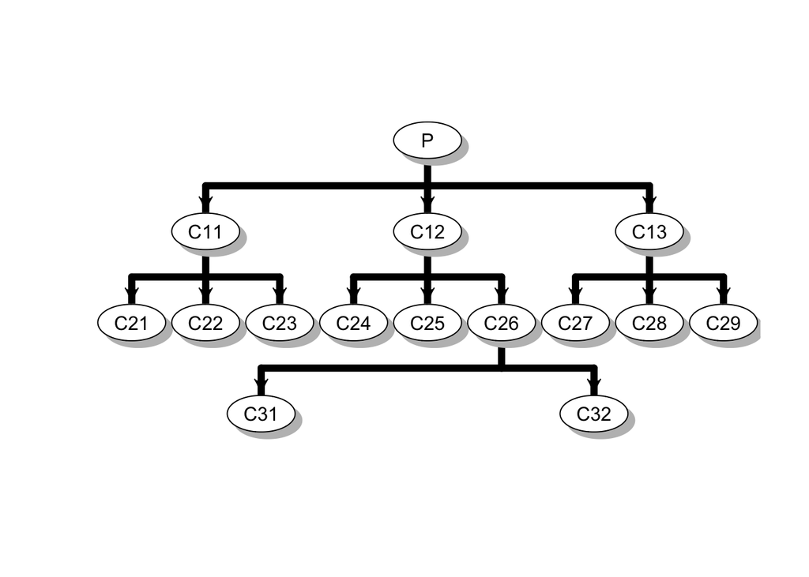

```r
C11 <- list( C21 = "C21",
             C22 = "C22",
             C23 = "C23")
C26 <- list( C31 = "C31",
             C32 = "C32")
C13 <- list( C27 = "C27",
             C28 = "C28",
             C29 = "C29")
C12 <- list( C24 = "C24",
             C25 = "C25",
             C26 = C26)
P   <- list( C11 = C11,
             C12 = C12,
             C13 = C13)

# subtree rooted at C12
P[[2]]
P$C12

# subtree (leaf) rooted at C24
P[[c(2,1)]]
P$C12$C24

# subtree rooted at C26
P[[c(2,3)]]
P$C12$C26

# subtree (leaf) rooted at C31
P[[c(2,3,1)]]
P$C12$C26$C31
```

## Date Frame

Inheriting from matrix and list, data.frame is a container general enough for us to study a dataset. It permits inhomogeneous data types across columns (components in a list) but forces the components of the list to be vectors of homogeneous length (so as to be columns in a matrix). For example, the following creates a score table of 3 students.

```r
students <- data.frame( id = factor(c("001", "002", "003")), # ids are characters
                        score_A = c(95, 97, 90),          # scores are numericss
                        score_B = c(80, 75, 84))
students
```

To access the score_A of student 003, one can follow the manner in a matrix: `students[3,2]`, or that in a list: `students[[[2]][3]`, `students[["score_A"]][3]` or `students$score_A[3]`.

**Exercise 4.** *(5 pt)* Applying the conditional selection technique (see the section “indexing” and do not use *subset*), extract the record of student 003 i.e their id number, and their scores in the two tests.

```r
student_003 <- students[students$id == "003",]
student_003
```

```
##    id score_A score_B
## 3 003      90      84
```

One can also create a matrix or a legitimate list first and then convert it into a data.frame as follows.

```r
scores <- matrix(c(95, 97, 90, 80, 75, 84), 3, 2)
scores <- data.frame(scores)
colnames(scores) <- c("score_A", "score_B")
id <- c("001", "002", "003")
students1 <- cbind(id, scores)
students2 <- data.frame( list( id      = c("001", "002", "003"),
                               score_A = c(95, 97, 90),
                               score_B = c(80, 75, 84))
                         )
```

**Exercise 5.** *(10 pt)* Create a data.frame object to display the calendar for Jan 2018 as follows.

```r
## Sun Mon Tue Wed Thu Fri Sat
##      NY   2   3   4   5   6
##   7   8   9  10  11  12  13
##  14 MLK  16  17  18  19  20
##  21  22  23  24  25  26  27
##  28  29  30  31
matrix <- matrix(c(NA,"NY",2:14,"MLK",16:31,rep(NA,3)), 5, 7,byrow=TRUE)
df <- data.frame(matrix)
colnames(df) <- c("Sun", "Mon","Tue","Wed","Thu","Fri","Sat")
df
```

```
##    Sun Mon Tue Wed  Thu  Fri  Sat
## 1 <NA>  NY   2   3    4    5    6
## 2    7   8   9  10   11   12   13
## 3   14 MLK  16  17   18   19   20
## 4   21  22  23  24   25   26   27
## 5   28  29  30  31 <NA> <NA> <NA>
```

Ignore the ## symbols this was just so the above acts like a comment in R.

1) The character object `""` for the spaces; 2) the option `row.names = FALSE` in `print` function.

## Factors

Factor is a special data structure in **R** in representing categorical variables and facilitating the data labels and subgroups. It’s basically a character vector that keeps track of its distinct values called levels. Consider the longitudinal layout of the previous score table.

```r
id        <- factor(rep(c("001","002","003"), 2))
subj      <- rep(c("A","B"), each = 3)
score     <- c(95, 97, 90, 80, 75, 84)
students3 <- data.frame(id, subj, score)  # try cbind(id, subj, score) to see the difference

# students3$id and students3$subj are automatically formatted as factors
class(students3$id)
```

```
## [1] "factor"
```

```r
levels(students3$id)
```

```
## [1] "001" "002" "003"
```

```r
class(students3$subj)
```

```
## [1] "character"
```

```r
levels(students3$subj)
```

```r
# combind student 003 with 002 via level rename
students4 <- students3    # work on a copy in case of direct modification of students3
levels(students4$id)[3] <- "002"
levels(students4$id)
```

```
## [1] "001" "002"
```

```r
students4
```

```
##    id subj score
## 1 001    A    95
## 2 002    A    97
## 3 002    A    90
## 4 001    B    80
## 5 002    B    75
## 6 002    B    84
```

The `factor` function applied to a character vector creates a natural factor. The `gl` and `cut` functions are also useful approaches to patterned factors that are generated from numeric variables.

**Exercise 6.** *(5 pt)* Create a factor variable `grade` in `students3`, where the `score` variable is divided into $[90,100]$, $[80,90)$ and $[0,80)$ corresponding to A, B and C in `grade` respectively.

**Hint.** Functions `cut` to obtain the grades and `transform` to obtain the students5 from stuents3.

```r
subj=cut(students3[["score"]], breaks = c(0,80,90,100),right=FALSE,labels=c("C","B","A"))
students5<-students3
students5$grade=subj
students5
```

```
##    id subj score grade
## 1 001    A    95     A
## 2 002    A    97     A
## 3 003    A    90     A
## 4 001    B    80     B
## 5 002    B    75     C
## 6 003    B    84     B
```

## Operations and Functions

Note that scalar operations on vectors usually apply componentwise.

- **Arithmetic operations:** `+`, `-`, `*`, `/`, `^`, `%/%` (exact division), `%%` (modulus), `sqrt()`, `exp()`, `log()`
- **Logical operations**
  - And `&`, `&&`; or `|`, `||`; not `!`
  - Comparisons: `<`, `<=`, `>`, `>=`, `==` (different from `=`), `!=`
  - Summary functions: `all()`, `any()`
- **Summary statistics:** `length`, `max`, `min`, `sum`, `prod`, `mean`, `var`, `sd`, `median`, `quantile`
- **Matrix operations**
  - Matrix multiplication: `%*%` (different from `*`)
  - Related functions: `t`, `solve`, `det`, `diag`, `eigen`, `svd`, `qr`
  - Marginal operations: `apply`
- **Factors:** `tapply` (to apply operations/functions grouped by a factor)

**Exercise 7.** *(10 pt)* Without using the `var` and `scale` functions, compute the sample mean and sample covariance `X.var` of the data matrix `X` as in **Exercise 2.** More precisely, think of the $i$-th row of the matrix as observation of features for $i$-th individual.

**a** Create a 4-dimensional vector called `mu` where the $i$-th row is the mean of the $i$-th column of $X$.

```r
mu=apply(X,c(2),mean)
mu
```

```
## [1] 1.250 0.875 1.750 1.250
```

**b** Create a four-dimensional matrix `X.var`

$$X.var = \frac{1}{3} \sum_{i=1}^4 (\mathbf{x}_{i\cdot} - \mu)(\mathbf{x}_{i\cdot} - \mu)^T$$
where $\mathbf{x}_{i.}$ is the $i$-th row.

```r
X.var<-(1/3)*rowSums((X-mu)^2)
X.var
```

```
## [1] 3.75000000 4.18750000 2.25000000 0.08333333
```

**Exercise 8.** *(10 pt)* Imagine that we wanted to make students aware for each of their subjects, the average score of all other students in that subject. Create a variable (or column) called `score.mean` in `students3`, where next to each student and subject, the value of the score.mean is the average value of all students taking that subject.

```r
students6=students3
score.mean=rep(tapply(students3[['score']],students3[["subj"]],mean),each=3)
students6$score.mean=score.mean
students6
```

```
##    id subj score score.mean
## 1 001    A    95   94.00000
## 2 002    A    97   94.00000
## 3 003    A    90   94.00000
## 4 001    B    80   79.66667
## 5 002    B    75   79.66667
## 6 003    B    84   79.66667
```

### Writing your own functions

It’s convenient to create a user-defined **R** function, where you might encapsulate a standard, complicated or tedious procedure/algorithm in a “black box” like any built-in functions as mentioned above, so that other users might only need to care about the input and output of your function regardless the details. See the following toy example.

```r
my.fun <- function(x, y)
{
  # This function takes x and y as input
  # It returns a list that contains the mean of x, y respectively and their difference
  mean.x    <- mean(x)
  mean.y    <- mean(y)
  mean.diff <- mean.x - mean.y
  output    <- list(mean_of_x = mean.x,
                    mean_of_y = mean.y,
                    mean_diff = mean.diff)
  return(output)
}
x <- runif(50, 0, 1)  # simulate 50 numbers from U[0,1]
y <- runif(50, 0, 3)  # simulate 50 numbers from U[0,3]
my.fun(x, y)
```

## Flow Control

To help you write down your own **R** programs, the following examples familiarize you with the conditional statements and loops.

### Conditional Statements

```r
mymax.if <- function(x, y)
{
  # The mymax function returns the larger one among x and y
  if (x > y)
  {
    message("The first argument is larger!")
    return(x)
  }
  else if (x < y)
  {
    message("The second argument is larger!")
    return(y)
  }
  else
  {
    message("Equal!")
    return(x)
  }
}
mymax.if(3, 4)
mymax.if(4, 3)
mymax.if(3, 3)
```

### Loops

```r
factorial <- function(n)
{
  # It computes the factorial of the natural number n
  if(n == 0) return(1) else if(n < 0 | n != as.integer(n)) stop("Please input a natural number!")
  n.fac <- 1

  # for loops
  for(i in 1:n)
    n.fac <- i * n.fac

  # while loops
  ## i <- 1
  ## while(i <= n)
  ## {
  ##   n.fac <- i * n.fac
  ##   i <- i + 1
  ## }

  # repeat loops
  ## i <- 1
  ## repeat
  ## {
  ##   n.fac <- i * n.fac
  ##   i <- i + 1
  ##   if (i > n) break    # attention to the usage of break
  ## }

  return(n.fac)
}

double.factorial <- function(n)
{
  # It computes the double factorial of the natural number n
  if(n == 0) return(1) else if(n < 0 | n != as.integer(n)) stop("Please input a natural number!")
  n.doubfac <- 1
  for(i in 1:n)
    if(i %% 2 == n %% 2)
      n.doubfac <- i * n.doubfac
    else next    # attention to the usage of next
  return(n.doubfac)
}

factorial(6)
prod(1:6)
double.factorial(6)
double.factorial(5)
factorial(0)
## factorial(6.5)
## factorial(-6)
```

**Exercise 9.** *(15 pt)* The bisection method if a root-finding algorithm from numerical analysis to find a root of a continuous function in an interval $[a,b]$ once you know that function has different signs at the end points of the interval (i.e. $f(a)< 0, f(b)>0$ or vice-versa). Read about this in the [Wikipedia link](https://en.wikipedia.org/wiki/Bisection_method).

Write a function `bisect(f, lower, upper, tol = 1e-6)` to find the root of the univariate function `f` on the interval [`lower`, `upper`] with precision tolerance $\le$ `tol` (defaulted to be $10^{-6}$) via bisection, which returns a list consisting of `root`, `f.root` (`f` evaluated at `root`), `iter` (number of iterations) and `estim.prec` (estimated precision). Apply it to the function
$$f(x) = x^3 - 2x - 1$$
on $[1,2]$ with precision tolerance $10^{-6}$. Compare it with the built-in function `uniroot`.

```r
num_iter=0
lower = 0
upper= 2
last= 999

func<- function(value){
  return(value^3-2*value-1)
}

bisect<-function(f,lower,upper,tol=1e-6){
 mid=(lower+upper)/2
  while(func(mid)!=0&&abs(last-func(mid))>tol){
    if(func(mid)<0) lower=mid
    if(func(mid)>0) upper=mid
    num_iter=num_iter+1
    last=func(mid)
    mid=(lower+upper)/2
  }
  return(list(root=mid,f.root=func(mid),iter=num_iter,estim.prec=last-func(mid)))
}

mid=bisect(func,lower,upper)
mid
```

```
## $root
## [1] 1.618034
##
## $f.root
## [1] 9.609629e-08
##
## $iter
## [1] 23
##
## $estim.prec
## [1] 6.978634e-07
```

```r
uniroot(func,c(0,3))
```

```
## $root
## [1] 1.618033
##
## $f.root
## [1] -6.59994e-06
##
## $iter
## [1] 7
##
## $init.it
## [1] NA
##
## $estim.prec
## [1] 6.103516e-05
```

The results are similar to each other whereas the uniroot reaches the final answer with less iterations but less precision.

## Input/Output

`scan` and `read.table` are two main functions to read data. The main difference of them lies in that `scan` reads one component (also called “field”) at a time but `read.table` reads one line at a time. Hence `read.table` requires the data to be well-structured as a table so as to create a data.frame in **R** automatically, while `scan` can be flexible but might require effort in manipulating data after reading. Their usages are quite similar. One should pay attention to the frequently used options `file`, `header`, `sep`, `dec`, `skip`, `nmax`, `nlines` and `nrows` in their **R** documents.

`write.table` is a converse function against `read.table`, while their usages are almost identical. To get familiar with thier features, explore in the next exercise.

To read inline, one can specify `file = stdin()` (or omitted in `scan` function). In that case, it reads from console that the user can input line-by-line, or from the subsequent lines in a program script, until an empty line is read. However, such a trick is NOT compatible in **RMarkdown**.

If you have your data stored in another format, *e.g.* EXCEL or SAS dataset, then you can output it this as a CSV file and read in **R** via `read.csv` function (almost identical to `read.table`).

**Exercise 10** *(16 pt)* In the folder for HW 1, you can find data on UNC salaries as a unc_salary_data.csv file (all of which are publicly available and scraped by Ryan Thornburg).

**a** Read the data using read.csv into a data frame called `salaries`

```r
salaries=read.csv("unc_salary_data.csv")
head(salaries)
```

```
##                        name campus                          dept
## 1            AARON, NANCY G UNC-CH             Romance Languages
## 2     ABARBANELL, JEFFERY S UNC-CH Kenan-Flagler Business School
## 3              ABARE, BETSY UNC-CH  Institute of Marine Sciences
## 4            ABATE, AARON B UNC-CH       Medicine Administration
## 5        ABATEMARCO, JODI M UNC-CH           School of Education
## 6 ABBOTT-LUNSFORD, SHELBY L UNC-CH       Medicine Administration
##                     position                        exempt2 employed hiredate
## 1            Senior Lecturer                         Exempt        9 20030701
## 2        Associate Professor                         Exempt        9 19990101
## 3        Research Technician Subject to State Personnel Act       12 20110912
## 4      Accounting Technician Subject to State Personnel Act       12 20090420
## 5 Student Services Assistant Subject to State Personnel Act       12 20120103
## 6              HR Consultant Subject to State Personnel Act       12 20051003
##   fte     status stservyr statesal nonstsal totalsal age
## 1   1 Fixed-Term       11    46350        0    46350  55
## 2   1 Continuing       17   173000        0   173000  57
## 3   1  Permanent        3        0    38170    38170  54
## 4   1  Permanent        5        0    50070    50070  29
## 5   1  Permanent        2    41696        0    41696  35
## 6   1  Permanent       15    56588     4412    61000  41
```

Use `str(salaries)` and `head(salaries)` to get an idea of the data set.

**b** Make a new data frame called `relevant` consisting only of the columns: name, dept, age,totalsal. (Hint: consider the `subset` function).

```r
relevant=salaries[c("name","dept","age","totalsal")]
head(relevant)
```

```
##                        name                          dept age totalsal
## 1            AARON, NANCY G             Romance Languages  55    46350
## 2     ABARBANELL, JEFFERY S Kenan-Flagler Business School  57   173000
## 3              ABARE, BETSY  Institute of Marine Sciences  54    38170
## 4            ABATE, AARON B       Medicine Administration  29    50070
## 5        ABATEMARCO, JODI M           School of Education  35    41696
## 6 ABBOTT-LUNSFORD, SHELBY L       Medicine Administration  41    61000
```

**c** Make a new data frame called `top_200` consisting of the information in `relevant` of faculty who make more than $200,000.

```r
top_200=relevant[["totalsal"]]>200000
top_200=relevant[top_200,]
head(top_200)
```

```
##                  name                       dept age totalsal
## 41     ADAMS, SASHA D                    Surgery  42   271000
## 50 ADAMSON, WILLIAM T                    Surgery  50   410000
## 56  ADIMORA, ADAORA A                   Medicine  58   230614
## 71   AHALT, STANLEY C Renaissance Computing Inst  60   257940
## 91    AKINTEMI, OLA B                 Pediatrics  60   205919
## 94   AKULIAN, JASON A                   Medicine  38   230000
```

**d** Choose 3 departments that you are interested in. Compute the average salary of faculty in these 3 departments.

```r
apart=c("Psychology","Surgery","Medicine")
choose_3= subset(relevant,dept %in% apart)
tapply(choose_3$totalsal,choose_3$dept,mean)
```

```
##   Medicine Psychology    Surgery
##  139203.87   78635.56  201917.40
```

# Probability and Distributions

This section explores how to create “randomness” in **R** and obtain probabilistic quantities.

## Discrete Random Sampling

Much of the earliest work in probability theory starts with random sampling, *e.g.* from a well-shuffled pack of cards or a well-stirred urn. The `sample` function applies such procedure to a vector in **R**. Learn more from the **R** documents.

The following exercise means to create a five-fold cross-validating sets, which would be the starting point to assess the performance of a learned machine in, for example, classification errors.

**Exercise 11.** *(10 pt)* `iris` is a built-in dataset in **R**. Check `?iris` for more information. This dataset has data on 50 flowers each from 3 species of Iris (setosa, versicolor, and virginica). Randomly divide `iris` into five subsets `iris1` to `iris5` (without replacement), thus each subset has 30 rows of the iris data and further stratified to `iris$Species` (namely every subset should have 10 rows from each of the 3 species).

```r
x=iris
x=split(x, sample(rep(1:5,each=30)))
iris1=x$"1"
iris2=x$"2"
iris3=x$"3"
iris4=x$"4"
iris5=x$"5"

iris.5fold <- list(iris1, iris2, iris3, iris4, iris5)
iris.5fold
```

```
## [[1]]
##     Sepal.Length Sepal.Width Petal.Length Petal.Width    Species
## 15           5.8         4.0          1.2         0.2     setosa
## 19           5.7         3.8          1.7         0.3     setosa
## 22           5.1         3.7          1.5         0.4     setosa
## 23           4.6         3.6          1.0         0.2     setosa
## 27           5.0         3.4          1.6         0.4     setosa
## 29           5.2         3.4          1.4         0.2     setosa
## 34           5.5         4.2          1.4         0.2     setosa
## 35           4.9         3.1          1.5         0.2     setosa
## 39           4.4         3.0          1.3         0.2     setosa
## 51           7.0         3.2          4.7         1.4 versicolor
## 53           6.9         3.1          4.9         1.5 versicolor
## 56           5.7         2.8          4.5         1.3 versicolor
## 57           6.3         3.3          4.7         1.6 versicolor
```

[output cut: 149 more lines]

## Distributions

**R** is endowed with a set of statistical tables. To obtain the density function, cumulative distribution function (CDF), quantile (inverse CDF) and pseudo-random numbers from a specific distribution, one only needs to prefix the distribution name given below by `d`, `p`, `q` and `r` respectively.

| **Distributions** | **R Names** | **Key Arguments** |
| --- | --- | --- |
| Uniform | `unif` | `min`, `max` |
| Normal | `norm` | `mean`, `sd` |
| $\chi^2$ | `chisq` | `df`, `ncp` |
| Student’s t | `t` | `df`, `ncp` |
| F | `f` | `df1`, `df2`, `ncp` |
| Exponential | `exp` | `rate` |
| Gamma | `gamma` | `shape`, `scale` |
| Beta | `beta` | `shape1`, `shape2`, `ncp` |
| Logistic | `logis` | `location`, `scale` |
| Binomial | `binom` | `size`, `prob` |
| Poisson | `pois` | `lambda` |
| Geometric | `geom` | `prob` |
| Hypergeometric | `hyper` | `m`, `n`, `k` |
| Negative Binomial | `nbinom` | `size`, `prob` |

Check from their plots.

```r
plot(dnorm, xlim = c(-5, 5))   # bell curve of Normal density
plot(plogis, xlim = c(-5, 5))  # Logistic/Sigmoid function (CDF of Logistic distribution)
```

The following two-sample t-test shows the usages of `qt`, `pt` and `rnorm`. Recall that a two-sample homoscedastic t-test statistic is
$$\hat{\sigma}^2 = {(n_X - 1)S_X^2 + (n_Y - 1)S_Y^2 \over n_X + n_Y -2}, \quad T = {\bar{X} - \bar{Y} \over \hat{\sigma}\sqrt{ {1 \over n_X} + {1 \over n_Y}}} \stackrel{d}{\sim} t_{n_X + n_Y - 2} \text{ under } H_0:\ \mu_X = \mu_Y.$$

```r
twosam <- function(x, y, alpha = 0.05)
{
  # It conducts a two-sample homoscedastic t-test on x and y
  n.x       <- length(x); n.y    <- length(y)
  mean.x    <- mean(x);   mean.y <- mean(y)
  var.x     <- var(x);    var.y  <- var(y)
  mean.diff <- mean.x - mean.y
  df        <- n.x + n.y - 2
  sigma     <- ((n.x - 1) * var.x + (n.y - 1) * var.y) / df
  var.diff  <- (1/n.x + 1/n.y) * sigma
  t         <- mean.diff / sqrt(var.diff)
  t.alpha   <- qt(1 - alpha/2, df)
  output    <- list(t       = t,
                    df      = df,
                    p.value = 2 * pt(-abs(t), df),
                    confint = c(lower = mean.diff - sqrt(var.diff) * t.alpha,
                                upper = mean.diff + sqrt(var.diff) * t.alpha),
                    mu      = c(mu.x = mean.x, mu.y = mean.y),
                    sigma   = sigma)
  return(output)
}
x1 <- rnorm(40, 0, 1)
x2 <- rnorm(50, 0, 1)
x3 <- rnorm(50, 1, 1)
twosam(x1, x2)
t.test(x1, x2, var.equal = TRUE)
twosam(x1, x3)
t.test(x1, x3, var.equal = TRUE)
```

# Data Exploration and Manipulation

Data analysis in **R** starts with reading data in a data.frame object via `scan` and `read.table` as discussed before. Then one would explore the profiles of data via various descriptive statistics whose usages are also introduced in the previous sections. Calling the `summary` function with a data.frame input also provides appropriate summaries, *e.g.* means and quantiles for numeric variables (columns) and frequencies for factor variables.

This section explores more features that can be achieved through **R**.

## Tables

Statistician often works with catergorical variables via tables. Even for continuous variables, segregating them into catergorical ones in a meaningful way might provide more insights. `table` function generates frequency tables for factor variables. Multi-way tables, marginal and proportional displays and independence test are explored in the following example. Recall that the Pearson’s $\chi^2$ independence test statistic on an $r$-by-$c$ contingency table
$$\chi^2 = \sum_{i=1}^r\sum_{j=1}^c{\left({n_{ij} - {n_{i\cdot}n_{\cdot j} \over n_{\cdot\cdot}} }\right)^2 \over {n_{i\cdot}n_{\cdot j}/ n_{\cdot\cdot}} } \stackrel{d}{\approx} \chi^2_{(r-1)(c-1)} \text{ under } H_0: p_{ij} = p_i p_j.$$

```r
# Discretize the numeric variables
iris0 <- transform(iris,
                   Sepal.Length = cut(Sepal.Length, 4:8),
                   Sepal.Width  = cut(Sepal.Width,  1:5),
                   Petal.Length = cut(Petal.Length, 0:7),
                   Petal.Width  = cut(Petal.Width,  0:3))

attach(iris0)   # attach function makes columns assessible as usual variables
table(Sepal.Width)
iris.table0 <- table(Petal.Width)
iris.table0
iris.table1 <- table(Sepal.Width, Petal.Width)
iris.table1
iris.table2 <- table(Sepal.Width, Petal.Width, Species)
iris.table2

# flat table in a sligtly different display
ftable(Sepal.Width, Petal.Width)
ftable(Species, Sepal.Width, Petal.Width)

# data.frame display
data.frame(iris.table1)
data.frame(iris.table2)

# marginal display
margin.table(iris.table1, 1)
margin.table(iris.table1, 2)

# proportional display relative to the (margin) total
prop.table(iris.table1)
prop.table(iris.table1, 1)
prop.table(iris.table1, 2)
prop.table(iris.table2, 1)
prop.table(iris.table2, c(1,3))

# conduct chi-square independence test
chisq.test(iris.table1)   # warning message due to some frequency entry <= 5

# plots
pie(iris.table0, main="Petal.Width")
barplot(t(iris.table1), beside = TRUE,
        xlab = "Sepal.Width", ylab = "Petal.Width", legend.text = colnames(iris.table1))

detach(iris0)   # paired with attach function
```

## Plots

Compared to other statistical softwares in data analysis, **R** is good at graphic generation and manipulation. The plotting functions in **R** can be classified into the high-level ones and the low-level ones. The high-level functions create complete, new plots on the graphics device while the low-level functions only add extra information to the current plots.

`plot` is the most generic high-level plotting function in **R**. It will be compatble with most class of objects that the user input and produce appropriate graphics. For example, a numeric vector input results in a scatter plot with respect to its index and a factor vector results in a bar plot of its frequency table. Advanced class of object like `lm` (fitted result by a linear model) can also be called in `plot`. Methods will be discussed in specific documents like `?plot.lm`.

Other plotting features include

- High-level plotting options: `type`, `main`, `sub`, `xlab`, `ylab`, `xlim`, `ylim`
- Low-level plotting functions
  - **Symbols:** `points`, `lines`, `text`, `abline`, `segments`, `arrows`, `rect`, `polygon`
  - **Decorations:** `title`, `legend`, `axis`
- Environmental graphic options (`?par`)
  - **Symbols and texts:** `pch`, `cex`, `col`, `font`
  - **Lines:** `lty`, `lwd`
  - **Axes:** `tck`, `tcl`, `xaxt`, `yaxt`
  - **Windows:** `mfcol`, `mfrow`, `mar`, `new`
- User interaction: `location`

I’ll suggest the beginners learn from examples and grab when needed instead of going over such an overwhelming brochure. The following sections illustrate two basic senarios in data analysis. More high-level plotting functions will also be introduced.

**Exercise 12** *(10 pt)*

**a** Recall the UNC salary data set. From the `salaries` data frame plot the number of CS faculty hired per year vs year.

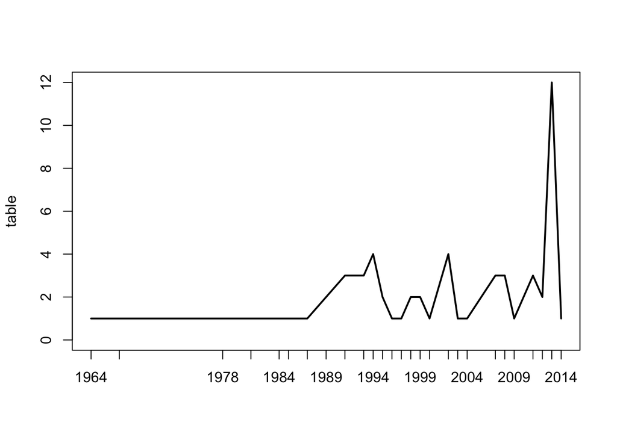

```r
salaries2=salaries
salaries2$hiredate=format(as.Date(as.character(salaries2$hiredate),format="%Y%m%d"),"%Y")
table=table(salaries2[salaries2$dept=="Computer Science",]$hiredate)
plot(table,type="l")
```

**b** Now add STOR, Math and Physics to the above plot

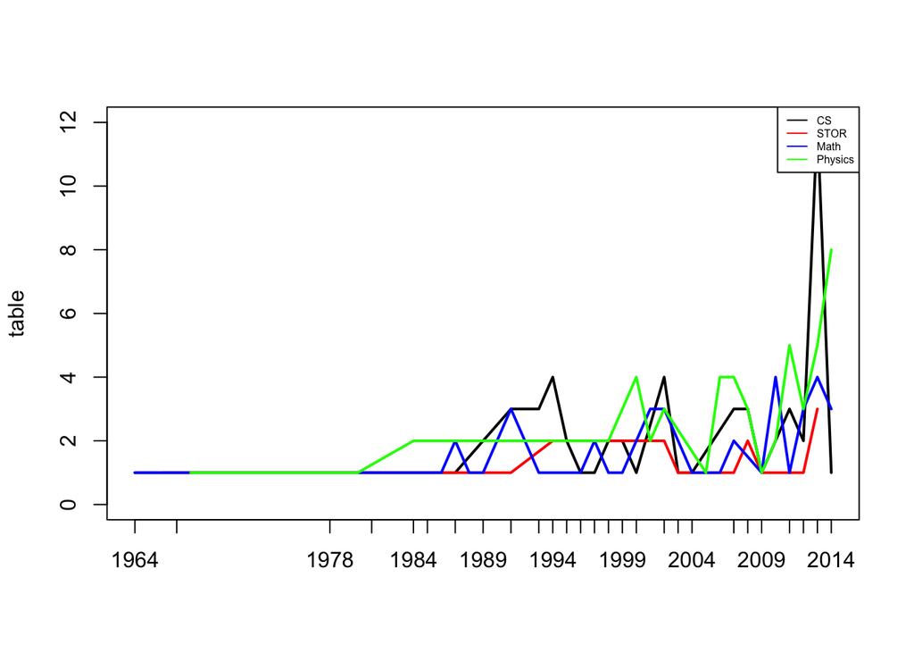

```r
salaries3=salaries2
choose=c("Statistics and Operations Res","Mathematics","Physics-Astronomy")
salaries3=subset(salaries3,dept %in% choose)
table1=table(salaries3[salaries3$dept=="Statistics and Operations Res",]$hiredate)
table2=table(salaries3[salaries3$dept=="Mathematics",]$hiredate)
table3=table(salaries3[salaries3$dept=="Physics-Astronomy",]$hiredate)
plot(table,type="l")
lines(table1,type="l",col="red")
lines(table2,type="l",col="blue")
lines(table3,type="l",col="green")
  legend("topright",
         legend = c("CS","STOR","Math","Physics"),
         col = c("black", "red","blue","green"), lty = 1, cex = 0.5)
```

### Access the empirical distribution

**Histogram:** The `hist` function creates a histogram in **R**, where the `breaks` and `freq` options are frequently called. The `barplot` function could also realize the same result as illustrated in section **Tables**.

**Kernel Density Curve:** The `density` function estimates an empirical density of the data and gives a `density` object. One can call `plot` function with such an object as input and picture a density curve, which is anticipated to closely envelop its historgram. Note that the `bw` (bandwidth) and `kernel` options should be carefully considered in methodology.

**Empirical CDF (ECDF):** The `ecdf` function generates an empirical CDF (`"ecdf"`) object that can be called by the `plot` function, which results in a step function graphic for the empirical cumulative distribution function. Creating a graph containing multiple CDFs or ECDFs visually displays the good-of-fitness or discrepancy among them. The statistically quantified Kolmogorov-Smirnov test with statistic
$$D_n = \sup_{x \in \mathbb{R}}|F_n(x) - F(x)|$$
realized by the `ks.test` function is based on it.

**Q-Q Plots:** “Q-Q” stands for the sample quantiles versus that of a given distribution or another sample. `qqnorm`, `qqline` and `qqplot` together is the set of functions in realizing it. **R** documents also illustrate how to create Q-Q plots against distributions other than Normal.

**Box-and-Whisker Plots:** With `boxplot` function in **R**, we can describe the data with box associated with certain quantiles and the whiskers for extremes. The box in the middle indicates “hinges” (nearly quartiles, see `?boxplot.stats`) and median. The lines (“whiskers”) show the largest/smallest observation that falls within a distance of 1.5 times the box size from the nearest hinge. If any observations fall farther away, the additional points are considered “extreme” values and are shown separately.

**Exercise 13.** *(15 pt)* The following code generates the ensuing plot about `Sepal.Length` in `iris`.

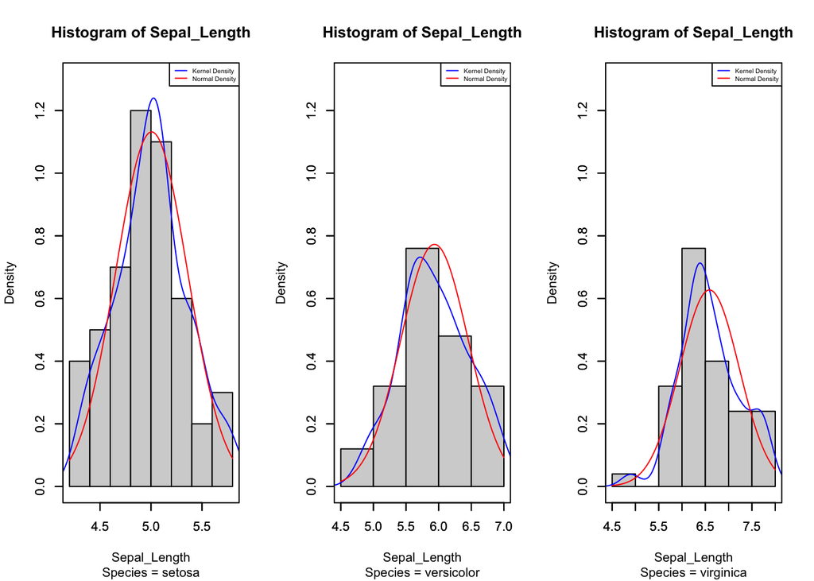

```r
opar <- par(mfrow = c(1,3))
for(l in levels(iris$Species))
{
  Sepal_Length <- subset(iris, Species == l, select = Sepal.Length)[[1]]
  h <- hist(Sepal_Length, sub = paste("Species =", l), ylim = c(0,1.3), freq = FALSE)

  par(new = TRUE)   # add to the current plot
  # Empirical density curve
  lines(density(Sepal_Length),
       xlim = range(h$breaks), ylim = c(0,1.3),  # to match the plotting range
       col = "blue",
       main = "", sub = "", xlab = "", ylab = ""    # to supress labels
       )
  par(new = TRUE)   # add to the current plot

  # Normal density curve
  curve(dnorm(x, mean = mean(Sepal_Length), sd = sd(Sepal_Length)),
        xlim = range(h$breaks), ylim = c(0,1.3),  # to match the plotting range
        col = "red",
        main = "", sub = "", xlab = "", ylab = ""    # to supress labels
        )

  legend("topright",
         legend = c("Kernel Density", "Normal Density"),
         col = c("blue", "red"), lty = 1, cex = 0.5)
}
```

```r
par(opar)
```

**Plot generated**:

[figure not shown]

Either modify the code above or use your own code to obtain similar plots with histograms, kernel density plots and normal density plots for the salary of faculty in CS, Math and Physics from UNC salary data.

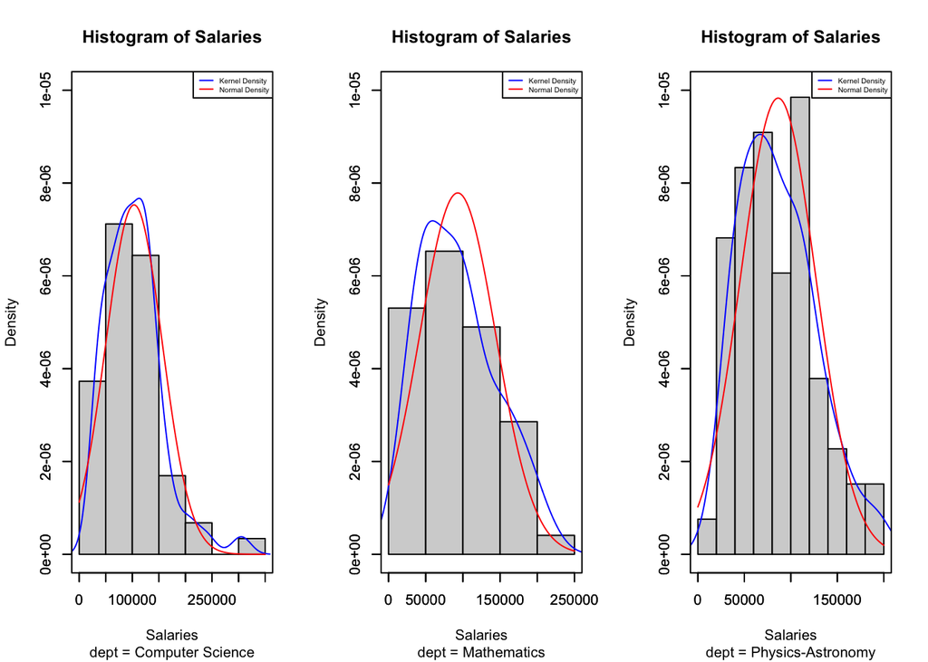

```r
opar <- par(mfrow = c(1,3))
choose=c("Computer Science","Mathematics","Physics-Astronomy")
salaries4=salaries
salaries4=subset(salaries4,dept%in%choose)
salaries4$dept <- as.factor(salaries4$dept)

for(l in levels(salaries4$dept))
{
  Salaries <- subset(salaries4, dept == l, select = totalsal)[[1]]
  h<-hist(Salaries, sub = paste("dept =", l),freq=FALSE,ylim=c(0,1e-5))

  par(new = TRUE)   # add to the current plot
  # Empirical density curve
  lines(density(Salaries),
       xlim = range(h$breaks),ylim=c(0,1e-5), # to match the plotting range
       col = "blue",
       main = "", sub = "", xlab = "", ylab = ""    # to supress labels
       )
  par(new = TRUE)   # add to the current plot

  # Normal density curve
  curve(dnorm(x, mean = mean(Salaries), sd = sd(Salaries)),
        xlim = range(h$breaks),ylim=c(0,1e-5),  # to match the plotting range
        col = "red",
        main = "", sub = "", xlab = "", ylab = ""    # to supress labels
        )

  legend("topright",
         legend = c("Kernel Density", "Normal Density"),
         col = c("blue", "red"), lty = 1, cex = 0.5)
}
```

```r
par(opar)
```